# BrainSpan dataset"

# 1. Assignment information

## 1.1 Background

- Professor’s webpage [link](https://joonan30.github.io/bsms222_123_an/)
- BSMS222 assignment [link](https://htmlpreview.github.io/?https://github.com/joonan30/bsms222_123_an/blob/master/assignment1.nb.html)
- Dataset : BrainSpan dataset
- Sumission format : R notebook html named “assignment1_081_Kim”
- Plotting rule : <= 2 plots, Multi-panel plots(`facet_wrap` or `cowplot`) are allowed
- Deadline : 17th Thu Oct, 10PM
- Evaludation policy
  1. **Accuracy** : How well you describe the dataset to your question in the R notebook?
     - Question에 집중하라
  2. **Flowing Data** : Whether/How many times you use `tidyverse` functions for data munging? Whether the code is briefly and efficiently written for your task (e.g. `%>%`)?
     - `tidyverse`의 ecosystem을 이해하며 데이터 변환을 효율적인 script로 구현하라.
     - [Tidy data there’s no need to start from scratch.](http://vita.had.co.nz/papers/tidy-data.pdf) - from wiki
     - 배운 것을 써먹어라.
  3. **Storytelling with Data** : Whether you fully utilize the dataset for your question? Whether you understand the aim and methods of the dataset?
  4. **Readability of your plot** : How much information you summarize into your plot?
     - 최대한 풀어서 써라.
  5. **Right visual format** : Whether you properly use color, scale, and data type for your data visualization.

## 1.2 My question and Strategy

### **Q : 뇌의 성별 결정에 miRNA에 의한 post-translational regulation이 어떠한 영향을 끼치는가?**

### 1.2.1. 성별에 따라 profile이 다른 miRNA의 indentification

```markdown
    step 1 ) MAplot -> volume cut-off setting
    step 2 ) Volcano plot
    step 3 ) select putative miRNA that determine the gender of the brain (named "bg-miRNA" => female : "bgF-miR", male : "bgM-miR")
```

[output not shown]

- 17. sexual identity와 brain gender identity는 항상 일치할 것인가?
  - annotation : biological sex (stands for sexual identity)

### 1.2.2. 생애 주기 내 성별에 따른 bgF-miR과 bgM-miR의 profile

- strategy 1 : using scatter plot

```markdown
x-axis : Age [year]
y-axis : Fold enrichment [log2(F/M)]
          - positive : Female enriched
          - negative : Male enriched
dot color : bgF-miR vs bgM-miR
```

[output not shown]

- strategy 2 : using HeatMap << I think it’s better

```markdown
x-axis : Age [year]
y-axis : bg-miR  >> clustering as week and strong
color : Fold enrichment [log2(F/M)]
```

[output not shown]

### 1.2.3. 성별 결정에 critical하다고 판단되는 시기를 mRNA profile을 통해 추정

### 1.2.4. critical time point를 miRNA profile과 matching

### 1.2.5. miRNA target prediction을 통하여 sex determination에 끼치는 영향 평가

# 2. Data set information

## 2.1 Description from assignment page

- The development of the prefrontal cortex (PFC) is an immensely complex process. It begins as a simple neural tube that derives from the embryonic ectoderm and gradually develops into mature organization through immensely complicated and strictly regulated molecular and cellular processes. Recent advances in genome sequencing enables profiling gene expression across human tissues and developmental stages. Here we use the RNA-seq transcriptomic dataset from the BrainSpan atlas, a foundational resource for studying transcriptional mechanisms involved in human brain development. With the subset of the **human dorsolateral prefrontal cortex**, we will explore how gene expression changes from early fetal to late adulthood.
- There are two papers on the dataset ([Kang et al. 2010](https://www.ncbi.nlm.nih.gov/pubmed/22031440), [Miller et al. 2014](https://www.ncbi.nlm.nih.gov/pmc/articles/PMC4105188/)). Please find background information - experimental design, techniques (RNA-seq), and findings for developing brain transcriptome.
- In the dataset, you will find three data frames.
  - e: RNA-seq expression
  - g: gene information
  - s: sample information

  For further information, please find the PDF link.

## 2.2 miRNA data information

### 2.2.1 RNA extraction method

```
    : QIAgen RNeasy PLUS kit method (non-phenolic RLT lysis)
```

*QIAgen RNeasy PLUS kit은 200ntd 이상의 RNA quality만을 보장하는 kit. small RNA를 관찰하기 위해서는 Phenolic buffer를 이용한 extraction을 이용해야 하는데, 이 방법으로 접근한 것에 대해서는 이유를 모르겠음.

### 2.2.2. Library preparation : TruSeq Small RNA sample Kit (Illumina, start with 1ug of total RNA)

### 2.2.3 Analysis

1. Preprocess to make trimmed reads between 16~36ntd
2. 1st Mapping : Mapping to miRBase DB (mature + precursor/hairpin) - using Bowtie(version 0.12.7) _argument: ‘-best’, ‘-strata’, maximum 2-base mismatch - reference as 17nt seed region of miRBase DB
3. 2nd Mapping : use unmapped read from 2) - piRNA : RNAdb(version2, Pang et al., 2005) - eRNA(enhancer RNA) : sequence from genomic coordinates defined in (Prabhakar et al., 2006) - tRNA : GtRNAdb(Chan, and Lowe et al., 2009) - mRNA : GENCODE(version 10, Harrow et al., 2006) - entries : RFam database (version 10.1, Gardner et al., 2009)
4. 3rd Mapping : use unmapped read from 3) - genome (hg19)

### 2.2.4. Normalization : represented by RPM value (normalized by the total number of mapped reads over all RNA species)

- 직접 확인해보니 RPM이 아닌 raw count로 reporting되어 있음
- in ‘README’ sheet : “Raw RNA-seq read-count data for microRNAs are contained for the isolated small RNA samples from the indicated structures and specimens.”

# 3. miRNA analysis

**Main Question : 성별에 따라 profile이 다른 miRNA의 indentification**

## 3.1 miRNA data download

- get miRNA xls files from WebSite directly

```
wget http://download.alleninstitute.org/brainspan/MicroRNA/MicroRNA.xls
```

```r
#install.packages('readxl')
library(readxl)
library(tidyverse)
```

```r
miRDB <- read_excel("MicroRNA.xls",
                    sheet="miRNA_rawCount",
                    col_names = TRUE)
```

```
* `` -> ...1
```

```r
#colnames(miRDB)
miRDB <- miRDB %>% rename("miRNA"="...1") #rename(NEW NAME = OLD NAME)
miRDB %>% head()
```

| miRNA | H376_X_53-A1C-L | H376_X_53-IPC-L | H376_X_53-ITC-L | H376_X_53-M1C-L | H376_X_53-MFC-L | H376_X_53-OFC-L | H376_X_53-S1C-L | H376_X_53-STC-L | H376_X_53-V1C-L | H376_X_53-VFC-L | H376_VIII_50-AMY-R | H376_VIII_50-CBC-R | H376_VIII_50-DFC-R | H376_VIII_50-HIP-R | H376_VIII_50-IPC-R | H376_VIII_50-ITC-R | H376_VIII_50-M1C-R | H376_VIII_50-MD-R | H376_VIII_50-MFC-R | H376_VIII_50-S1C-R | H376_VIII_50-STC-R | H376_VIII_50-STR-R | H376_VIII_50-V1C-R | H376_VIII_50-VFC-R | H376_X_50_A1C-L | H376_X_50_AMY-L | H376_X_50_CBC-L | H376_X_50_DFC-L | H376_X_50_IPC-L | … |
| --- | --- | --- | --- | --- | --- | --- | --- | --- | --- | --- | --- | --- | --- | --- | --- | --- | --- | --- | --- | --- | --- | --- | --- | --- | --- | --- | --- | --- | --- | --- |
| hsa-miR-26a-5p | 486795 | 445802 | 1839843 | 395746 | 2556621 | 476207 | 288385 | 1122531 | 1812042 | 1805487 | 93399 | 119633 | 878143 | 112494 | 1297659 | 1056373 | 484000 | 397734 | 464083 | 948079 | 929688 | 243818 | 1052500 | 788276 | 119814 | 87466 | 619065 | 662667 | 258627 | … |
| hsa-miR-181a-5p | 204187 | 137349 | 521372 | 113062 | 392610 | 135252 | 94190 | 339451 | 571515 | 355986 | 65894 | 82203 | 433316 | 101761 | 339517 | 155163 | 119316 | 547526 | 165085 | 517910 | 165326 | 728249 | 292828 | 110517 | 132361 | 132823 | 300407 | 282331 | 260955 | … |
| hsa-miR-143-3p | 106540 | 135639 | 246300 | 86316 | 385059 | 58935 | 63646 | 201955 | 387403 | 258691 | 26986 | 9549 | 341600 | 22027 | 413919 | 137265 | 116588 | 375745 | 283503 | 418752 | 116508 | 210868 | 310036 | 180321 | 109534 | 73815 | 20233 | 95434 | 237345 | … |
| hsa-let-7a-5p | 103526 | 99903 | 280448 | 52586 | 235163 | 61192 | 50502 | 177515 | 325408 | 264515 | 28418 | 70261 | 434178 | 45692 | 325251 | 136687 | 134821 | 538986 | 106613 | 363465 | 151648 | 295712 | 385744 | 149748 | 126765 | 121699 | 583682 | 282865 | 303088 | … |
| hsa-miR-9-5p | 90559 | 105489 | 368891 | 78541 | 380200 | 78102 | 51504 | 193352 | 585549 | 305131 | 35578 | 57997 | 301783 | 30450 | 400572 | 207261 | 145919 | 425883 | 138213 | 287545 | 120909 | 178052 | 416539 | 172071 | 50600 | 69972 | 508410 | 137607 | 150149 | … |
| hsa-miR-3182 | 87781 | 68218 | 187951 | 34335 | 162157 | 31882 | 35223 | 109412 | 123046 | 67266 | 1686 | 1369 | 11188 | 4295 | 13651 | 18301 | 5709 | 36127 | 5610 | 17148 | 13934 | 16213 | 10742 | 13724 | 4748 | 12430 | 80 | 1856 | 8791 | … |

- It’s not tidy >> but when converting RNA-seq data to tidy data, it’s gonna messy…. isn’t it? just try it!

## 3.2 miRNA dataset wrangling

### 3.2.1 Make it tidy! : wide to long

- donor 이름에 "_“과”-“가 규칙 없이 섞임. donor info sheet에는”.“로 이어져 있음 ==> 모두”."로 바꾸고, structure information은 다른 row로 분리

```
#prctice
c<-data_frame("sample"=c("H376_VIII_50-AMY-R","H376_VIII_51_CBC-R"))

c %>% mutate(sample=gsub("-","_",sample)) %>%
  separate(sample, sep="_",, into=c("t1", "t2", "t3", "structure", "side")) %>%
  mutate("age_group_BS"=t2) %>%
  unite(col="donor_name", t1, t2, t3, sep=".")

#  mutate("structure"=do.call('rbind',strsplit(sample,split="_"))[,4],
#         "new_name"=paste(do.call('rbind',strsplit(sample,split="_"))[,-4][,-5], collapse="."))
```

- application

```r
## wide -> long by `gather(key="정리 후 변수의 col 이름", value="정리 후 값의 col 이름",  정리할 행 규칙)`
miRDB <- miRDB %>% gather(key="donor_name", value="counts", starts_with('H376'), factor_key=FALSE)
miRDB %>% summarize("#_of_donor_and_structure"=n_distinct(donor_name))
```

| #_of_donor_and_structure |
| --- |
| 216 |

```r
## 변수 정리 : 필요한 data를 column으로 나누기 : "age_group" 변수 추출
miRDB<- miRDB %>% mutate(donor_name=gsub("-","_",donor_name)) %>%   #donor name을 하나의 규칙으로 정리
          separate(donor_name, sep="_", into=c("t1", "t2", "t3", "structure", "side")) %>%
          mutate("age_group_BS"=t2) %>%
          unite(col="donor_name", t1, t2, t3, sep=".") %>%
          mutate(age_group=case_when(age_group_BS %in% c("X", "XI") ~ "Adult",
                              age_group_BS %in% c("VI", "VII", "VIII", "IX") ~ "Youth",
                              TRUE ~ "Fetus"))
miRDB %>% summarize("distinct_#_of_donor"=n_distinct(donor_name))
```

| distinct_#_of_donor |
| --- |
| 18 |

### 3.2.2 Collecting gender information

- miRNA dataset에는 donor description이 없어 RNA-seq dataset의 `columns_metadata’를 이용하여 정보수집

```
wget https://www.brainspan.org/api/v2/well_known_file_download/267666525
>>filename : 267666525
file 267666525
>>267666525: Zip archive data, at least v2.0 to extract
unzip 267666525
```

```r
donor_info <- read_csv("columns_metadata.csv") %>%
              select(donor_name, age, gender) %>%
              unique()
donor_info
```

| donor_name | age | gender |
| --- | --- | --- |
| H376.IIA.51 | 8 pcw | M |
| H376.IIA.50 | 9 pcw | M |
| H376.IIB.50 | 12 pcw | F |
| H376.IIB.51 | 12 pcw | F |
| H376.IIB.52 | 12 pcw | F |
| H376.IIIA.50 | 13 pcw | M |
| H376.IIIA.51 | 13 pcw | F |
| H376.IIIA.52 | 13 pcw | M |
| H376.IIIB.50 | 16 pcw | M |
| H376.IIIB.51 | 16 pcw | M |

[output cut: 32 more lines]

- practice

```
#practice
expdf <- tibble(donor_name=c("H376_IIA_51", "H376_IIA_50"), value=c(1,2))
merge(expdf, donor_info, all.y = T)
count(expdf)
```

- application : `merge`를 이용하여 `miRDB` database 정의

```r
miRDB <- merge(miRDB, donor_info, by='donor_name' ,all.x=T)
miRDB %>% group_by(gender) %>% summarize("Number_of_donor"=n_distinct(donor_name))
```

| gender | Number_of_donor |
| --- | --- |
| F | 7 |
| M | 10 |
| NA | 1 |

- `NA` value : 한 sample에서 성별 정보가 누락된 것인가?

```r
miRDB %>% filter(gender %in% NA) %>% distinct(donor_name)
```

| donor_name |
| --- |
| H376.VII.50 |

- 실제로 직접 xls 파일을 확인해보니 description 정보 누락
- [BrainSpan](https://help.brain-map.org/download/attachments/3506181/Human_Brain_Seq_Stages.pdf?version=1&modificationDate=1433436980032&api=v2)에서 직접 확인 >> age = 6 pm, gender = FEMALE

```r
# 결측값 채우는 방식으로 누락된 정보 채우기
miRDB <- miRDB %>% mutate(gender = replace_na(gender, "F"), age = replace_na(age, "6 pm"))
miRDB %>% group_by(gender) %>% summarize("Number_of_donor"=n_distinct(donor_name))
```

| gender | Number_of_donor |
| --- | --- |
| F | 8 |
| M | 10 |

```r
miRDB %>% group_by(gender,age_group) %>%  summarize("Number_of_donor"=n_distinct(donor_name))
```

| gender | age_group | Number_of_donor |
| --- | --- | --- |
| F | Adult | 3 |
| F | Youth | 5 |
| M | Adult | 3 |
| M | Youth | 7 |

- 아쉽게도 Fetus의 miRNA data가 없음. 2차 성징 전후로 바뀌는 miRNA를 보아야 할 것. >> group : **Adult vs Youth**

```r
miRDB %>% group_by(gender,age_group) %>% filter(structure == "DFC") %>% summarize("Number_of_donor"=n_distinct(donor_name))
```

| gender | age_group | Number_of_donor |
| --- | --- | --- |
| F | Adult | 2 |
| F | Youth | 2 |
| M | Adult | 2 |
| M | Youth | 6 |

- 각 structure 별로 본 분석에 활용할만한 data가 존재하는지 확인
  - Sexual differenciation과 관련이 있다고 알려진 SCN을 비롯한 midbrain이 해당 dataset에 존재하지 않음.
  - “DFC” region에서의 분석을 중점적으로 다룸.

```r
miRDB %>% group_by(structure, gender,age_group) %>% summarize("Number_of_donor"=n_distinct(donor_name))
```

| structure | gender | age_group | Number_of_donor |
| --- | --- | --- | --- |
| A1C | F | Adult | 3 |
| A1C | F | Youth | 2 |
| A1C | M | Adult | 3 |
| A1C | M | Youth | 3 |
| AMY | F | Adult | 2 |
| AMY | F | Youth | 3 |
| AMY | M | Adult | 2 |
| AMY | M | Youth | 6 |
| CBC | F | Adult | 2 |
| CBC | F | Youth | 4 |

[output cut: 54 more lines]

### 3.2.3 Read normalization

- practice

```r
#group and calculate each group
exdf <- data_frame(donor = c("A", "A", "A", "B", "B", "B", "C", "C", "C"),
                   miR = c("miR1", "miR2", "miR3","miR1", "miR2", "miR3","miR1", "miR2", "miR3"),
                   read = c(2,4,6,3,6,9,4,8,12))
exdf %>% group_by(donor) %>%
          mutate(total_read = sum(read), RPM = read / sum(read) * 10^6)
```

| donor | miR | read | total_read | RPM |
| --- | --- | --- | --- | --- |
| A | miR1 | 2 | 12 | 166666.7 |
| A | miR2 | 4 | 12 | 333333.3 |
| A | miR3 | 6 | 12 | 500000.0 |
| B | miR1 | 3 | 18 | 166666.7 |
| B | miR2 | 6 | 18 | 333333.3 |
| B | miR3 | 9 | 18 | 500000.0 |
| C | miR1 | 4 | 24 | 166666.7 |
| C | miR2 | 8 | 24 | 333333.3 |
| C | miR3 | 12 | 24 | 500000.0 |

- application
  - pseudocount : Fold change 계산 시 결측치에 의한 누락을 방지하기 위하여 raw count에 1을 더함
    - Reference : [DESeq2](http://bioconductor.org/packages/devel/bioc/vignettes/DESeq2/inst/doc/DESeq2.html)

```r
miRDB <- miRDB %>%
    group_by(donor_name) %>%
    mutate(pseudocount = counts + 1) %>%
    mutate(RPM = pseudocount / sum(pseudocount) * 10^6) %>%
    mutate(log2RPM = log2(RPM))
miRDB %>% head()
```

| donor_name | miRNA | structure | side | counts | age_group_BS | age_group | age | gender | pseudocount | RPM | log2RPM |
| --- | --- | --- | --- | --- | --- | --- | --- | --- | --- | --- | --- |
| H376.IX.50 | hsa-miR-26a-5p | A1C | L | 271485 | IX | Youth | 11 yrs | F | 271486 | 8587.8839 | 13.068087 |
| H376.IX.50 | hsa-miR-181a-5p | A1C | L | 149968 | IX | Youth | 11 yrs | F | 149969 | 4743.9513 | 12.211873 |
| H376.IX.50 | hsa-miR-143-3p | A1C | L | 71369 | IX | Youth | 11 yrs | F | 71370 | 2257.6386 | 11.140599 |
| H376.IX.50 | hsa-let-7a-5p | A1C | L | 91289 | IX | Youth | 11 yrs | F | 91290 | 2887.7656 | 11.495738 |
| H376.IX.50 | hsa-miR-9-5p | A1C | L | 66629 | IX | Youth | 11 yrs | F | 66630 | 2107.6988 | 11.041453 |
| H376.IX.50 | hsa-miR-3182 | A1C | L | 7643 | IX | Youth | 11 yrs | F | 7644 | 241.8017 | 7.917681 |

- cf_ long form의 data에서 쉽게 연산 변환이 가능

### 3.2.4 DFC region만 분리하여 분석 진행할 dataset 만들기 : `miR_DFC`

```r
miR_DFC <- miRDB %>% filter(structure == "DFC")
#save(miR_DFC, file="./BrainSpan_miR_analysis/miR_DFC.RData") #뒷부분에서 메모리 부족으로 저장이 되지 않는 듯하여 RData로 나누어 저장 후 불러옴.
load('./BrainSpan_miR_analysis/miR_DFC.RData') # tidy form of miRNA expression information of DFC region
miR_DFC %>% group_by(gender, age_group) %>% summarize("Number_of_donor" = n_distinct(donor_name))
```

| gender | age_group | Number_of_donor |
| --- | --- | --- |
| F | Adult | 2 |
| F | Youth | 2 |
| M | Adult | 2 |
| M | Youth | 6 |

> 통계적 유의성을 고려하기에 n수가 부족하지만, human sample임에 의의를 두고 분석 진행

## 3.3 Differential expression analysis

### 3.3.1 성인에서만 성별에 따라 유의하게 차이가 있는 miRNA 찾기

#### 3.3.1.1 Fold change 계산하기 -> Fold_enrichment, sd of Fold_enrichment

- miRNA의 확률분포는 EVD 혹은 nagetive binomeal distribution을 따른다고 알려져 있으나, 본 실습에서는 단순화하여 normal distribution을 따른다 가정하고 실행.
- Practice
  - RPM to Log transformation에는 다양한 가능성이 있다.

  1> RPM으로 Fold change와 Average, Significance를 계산 후 한번에 log transformation

  2> RPM을 먼저 log transformation한 후 logRPM이라는 새로운 확률변수를 통하여 분석하는 방법

  3> RPM을 통하여 Expression과 Significance를 계산하고, Fold change는 각각의 경우의 수를 조합하여 sample 당 FC를 새로운 확률변수로 두어 계산하는 방법
  - 3>은 생물학에서 흔히 사용되지만, outlier에 매우 취약하다고 알려져 있음
  - 1> vs 2> 에 대해서는 사용자마다 논란이 있는 편

  > 이번 분석을 통하여 접근에 따른 차이를 관찰해보고자 함.

##### 3.3.1.1.1 RPM으로 연산을 마친 후 log transformation으로 visualization한 경우

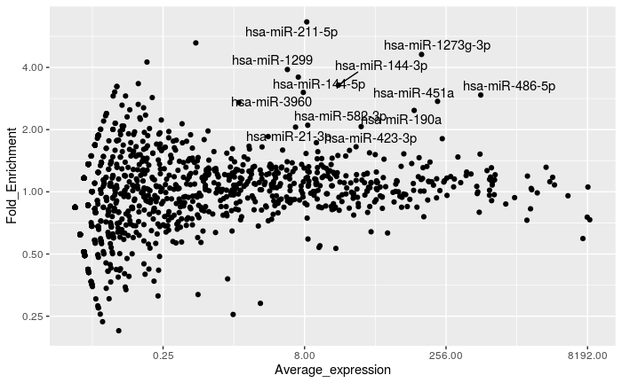

```r
#calculating by RPM
miR_DFC_DE<- miR_DFC %>% filter(age_group == "Adult") %>%
  group_by(gender, miRNA) %>%
  summarize("average"=mean(RPM)) %>%
  spread(key="gender", value="average") %>%
  mutate("Fold_Enrichment" = F/M, "Average_expression"= F+M/2)

#plotting
library(ggrepel)
miR_DFC_DE %>% ggplot(aes(Average_expression, Fold_Enrichment, na.rm=TRUE)) +
  geom_point() +
  scale_x_continuous(trans = "log2") +
  scale_y_continuous(trans = "log2") +
  geom_text_repel(aes(label=ifelse(Average_expression > 4 & (Fold_Enrichment > 2 | Fold_Enrichment<0.5) , miRNA, "")))
```

> 양수 쪽의 Fold Change에 치중된 경향 (labeling : |Fold expression| > 2, Average expression > 4)

##### 3.3.1.1.2 log2RPM이라는 확률변수를 먼저 정의한 경우

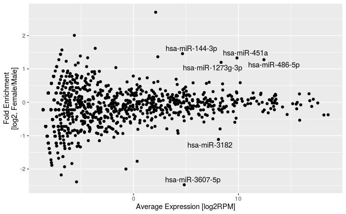

```r
#log2 transformation
miR_DFC_DE_log <- miR_DFC %>% filter(age_group == "Adult") %>%
  group_by(gender, miRNA) %>%
  summarize("average"=mean(log2RPM)) %>%
  spread(key="gender", value="average") %>%
  mutate("Fold_Enrichment" = F-M, "Average_expression"= F+M/2)

miR_DFC_DE_log %>% ggplot(aes(Average_expression, Fold_Enrichment)) +
  geom_point() +
  geom_text_repel(aes(label=ifelse((Average_expression > 4 & abs(Fold_Enrichment) > 1), miRNA, ""), )) +
  xlab("Average Expression [log2RPM]") +
  ylab("Fold Enrichment\n[log2, Female/Male]")
```

> 앞선 1번 방식보다 보수적 검정으로 보임. 보다 대칭적인 양상을 보이는 것으로 보아 증/감에 대한 bias가 적은 것으로 보임

##### 3.3.1.1.3. Fold Change의 standard deviation을 계산하기 위하여 `log2(Fold_Enrichment)=log2(Female)-log2(Male)`라는 확률변수를 정의하는 경우

- 생물학에서 Fold Change에 대한 통계적 검정을 위하여 흔히 사용하는 변수 -> Sequencing analysis에서도 적용이 될까?
- practice : t-test / f-test

```
#ptractice
a<- c(7.694240, 7.721688)
b<- c(7.971343, 7.178087)
str(t.test(a,b))
```

```
#practice
var.test(a,b)[["p.value"]]
```

- pactice

```r
temp <- miR_DFC %>%
  filter(miRNA %in% c("hsa-let-7c","hsa-let-7e-5p")) %>%
  select(miRNA, age_group, gender, RPM, age_group)
temp %>%
  group_by(miRNA, gender, age_group) %>%
  summarize("average"=mean(RPM)) %>%
  spread(key="gender",value="average") %>%
  mutate("Fold_Enrichment"=F/M)
```

| miRNA | age_group | F | M | Fold_Enrichment |
| --- | --- | --- | --- | --- |
| hsa-let-7c | Adult | 549.9037 | 567.7772 | 0.9685202 |
| hsa-let-7c | Youth | 903.3024 | 1110.2147 | 0.8136286 |
| hsa-let-7e-5p | Adult | 209.0971 | 197.8910 | 1.0566275 |
| hsa-let-7e-5p | Youth | 322.2293 | 403.5175 | 0.7985511 |

```r
temp <- temp %>%
          mutate(log2RPM=log2(RPM))
temp
```

| donor_name | miRNA | age_group | gender | RPM | log2RPM |
| --- | --- | --- | --- | --- | --- |
| H376.IX.50 | hsa-let-7c | Youth | F | 1045.6565 | 10.030193 |
| H376.IX.50 | hsa-let-7e-5p | Youth | F | 384.4976 | 8.586831 |
| H376.IX.51 | hsa-let-7c | Youth | M | 668.5585 | 9.384910 |
| H376.IX.51 | hsa-let-7e-5p | Youth | M | 213.9777 | 7.741317 |
| H376.IX.52 | hsa-let-7c | Youth | M | 303.7311 | 8.246651 |
| H376.IX.52 | hsa-let-7e-5p | Youth | M | 102.6739 | 6.681925 |
| H376.VI.52 | hsa-let-7c | Youth | M | 608.1045 | 9.248175 |
| H376.VI.52 | hsa-let-7e-5p | Youth | M | 171.5954 | 7.422867 |
| H376.VII.51 | hsa-let-7c | Youth | M | 1253.1525 | 10.291346 |
| H376.VII.51 | hsa-let-7e-5p | Youth | M | 784.3705 | 9.615391 |

[output cut: 14 more lines]

- aplication
- 해당 방법을 확정할지 모르는 상태였으므로 분산검정을 생략하고 등분산으로 가정

```r
FE_AVG <- function(tidy_df){
  ### input
  ### 1) tidy_df : tidy data format of miRNA expression file
  ### 2) fold_enrich_df
  fold_enrich_df = data.frame(miRNA=c(), FE_average=c(), FE_sd=c(), Exp_avg=c(), p_value=c())

  for(mir in unique(tidy_df$miRNA)){
    female_log_RPMs <- tidy_df %>% filter(miRNA == mir & gender == "F") %>% .$log2RPM
    male_log_RPMs <- tidy_df %>% filter(miRNA == mir & gender == "M") %>% .$log2RPM
    for(female_log_RPM in female_log_RPMs){
      logFE <- female_log_RPM - male_log_RPMs #logFE = log2Fold Enrichment / 새로운 확률변수를 만들어서 FC의 std를 통계적으로 구하고자 함
    }
    FEtemp <- data.frame(miRNA=mir,
                         FE_average=mean(logFE), # fold enrichment의 평균
                         FE_sd=sd(logFE), # fold enrichmnet의 standard deviation --> scatter plot의 standard deviation 추가
                         Exp_avg = mean(c(female_log_RPMs,male_log_RPMs)), # expression의 평균
                         Exp_sd = sd(c(female_log_RPMs,male_log_RPMs)), # expression의 sd
                         Q_score = -log10(t.test(female_log_RPMs,male_log_RPMs)[["p.value"]]))
    fold_enrich_df <- rbind(fold_enrich_df,FEtemp)
  }
  return (fold_enrich_df)
}


temp %>% filter(age_group=="Adult") %>% FE_AVG()
```

| miRNA | FE_average | FE_sd | Exp_avg | Exp_sd | Q_score |
| --- | --- | --- | --- | --- | --- |
| hsa-let-7c | 0.09855837 | 0.3144048 | 9.114477 | 0.2128556 | 0.04256377 |
| hsa-let-7e-5p | 0.14697347 | 0.5609169 | 7.641339 | 0.3330465 | 0.10035564 |

```r
miR_DFC_DE_each<- miR_DFC %>% filter(age_group=="Adult") %>% FE_AVG()
miR_DFC_DE_each
```

| miRNA | FE_average | FE_sd | Exp_avg | Exp_sd | Q_score |
| --- | --- | --- | --- | --- | --- |
| hsa-miR-26a-5p | 0.12896526 | 0.982033226 | 12.429274635 | 0.73229500 | 1.492515e-01 |
| hsa-miR-181a-5p | 0.86735023 | 0.383940959 | 12.160607980 | 1.06586189 | 9.034300e-02 |
| hsa-miR-143-3p | 1.06995940 | 0.568047086 | 10.647901284 | 1.38750370 | 9.926453e-02 |
| hsa-let-7a-5p | 0.05722985 | 0.511120221 | 11.710543360 | 0.30208963 | 1.591728e-02 |
| hsa-miR-9-5p | 0.49706755 | 0.176396432 | 11.191058547 | 0.38209421 | 2.963875e-02 |
| hsa-miR-3182 | 2.36648540 | 1.845231374 | 5.579760952 | 3.10105193 | 9.364912e-02 |
| hsa-miR-99b-5p | -1.62922583 | 3.164586199 | 11.343454325 | 2.20310313 | 1.412354e-02 |
| hsa-miR-30a-5p | 0.54811440 | 0.278546817 | 10.346436933 | 0.51880473 | 2.538037e-02 |
| hsa-miR-27b-3p | 1.15396289 | 0.024406411 | 10.637135835 | 1.00529854 | 1.740109e-02 |
| hsa-miR-191-5p | -0.15275394 | 0.679453956 | 10.400627276 | 0.40959351 | 1.223447e-01 |

[output cut: 990 more lines]

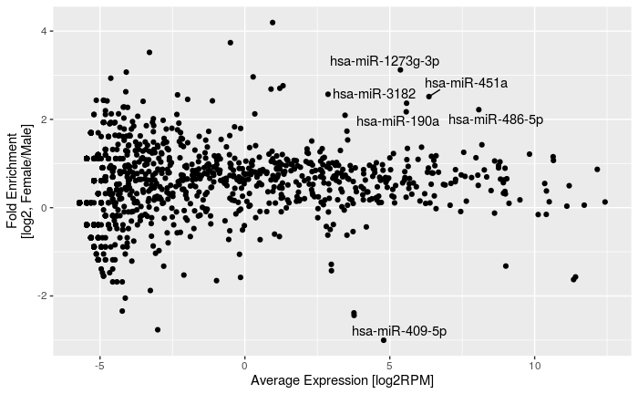

```r
#plotting
miR_DFC_DE_each %>% ggplot(aes(Exp_avg, FE_average)) +
  geom_point() +
  geom_text_repel(aes(label=ifelse((Exp_avg > 4 & abs(FE_average) > 2), as.character(miRNA), ""), )) +
  xlab("Average Expression [log2RPM]") +
  ylab("Fold Enrichment\n[log2, Female/Male]")
```

> 1),2)에 비하여 Fold Change가 퍼짐 -> 더욱 느슨한 검정이라 이해할 수 있음
- Fold Enrichment의 standard deviation을 유지할 수 있는 검정이므로 이후 다른 것도 살펴보고자 MA plot, Volcano plot을 관찰함.

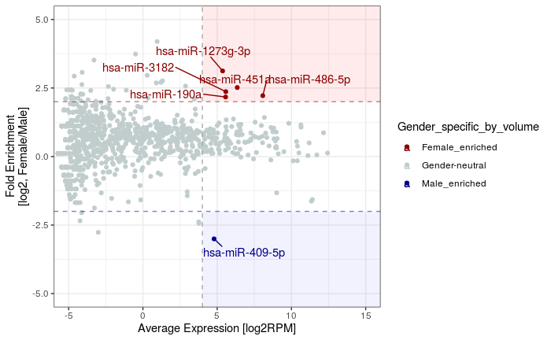

```r
miR_DFC_DE_each <- miR_DFC_DE_each %>% mutate(Gender_specific_by_volume=case_when((Exp_avg > 4 & FE_average > 2)~"Female_enriched",
                                                    (Exp_avg >4 & FE_average < -2)~"Male_enriched",
                                                    TRUE~"Gender-neutral"))

miR_DFC_DE_each %>% group_by(Gender_specific_by_volume) %>%
  ggplot(aes(Exp_avg, FE_average, color=Gender_specific_by_volume)) +
  geom_point() +
  annotate("rect", alpha = 0.1, ymin=2,ymax=6,xmin=4,xmax=20,fill="brown1") +
  annotate("rect", alpha = 0.05, ymin=-2,ymax=-6,xmin=4,xmax=20,fill="blue") +
  scale_color_manual(values=c("darkred", "#C1CDCD", "darkblue")) +
  xlab("Average Expression [log2RPM]") +
  ylab("Fold Enrichment\n[log2, Female/Male]")+
  geom_hline(yintercept = 2, colour="darkred", linetype="dashed", alpha=0.5) +
  geom_hline(yintercept = -2, colour="darkblue", linetype="dashed", alpha=0.5) +
  geom_vline(xintercept = 4, colour="darkgrey", linetype="dashed") +
  coord_cartesian(xlim =c(-5, 15), ylim = c(-5, 5)) +
  geom_text_repel(aes(label=ifelse((Exp_avg > 4 & FE_average > 2), as.character(miRNA), "")), nudge_x=-2.5, nudge_y=0.3) +
  geom_text_repel(aes(label=ifelse((Exp_avg > 4 & FE_average < -2), as.character(miRNA), "")), nudge_x=2, nudge_y=-0.5) +
  theme_bw()
```

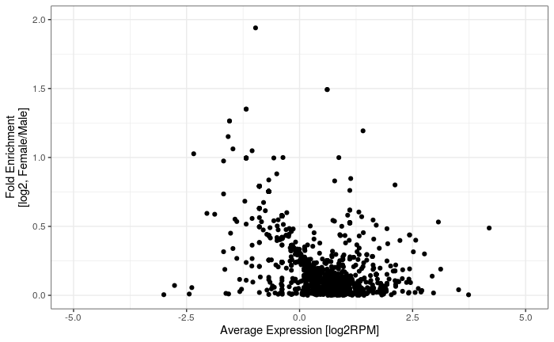

```r
miR_DFC_DE_each <- miR_DFC_DE_each %>% mutate(Gender_specific_by_volume=case_when((Exp_avg > 4 & FE_average > 2)~"Female_enriched",
                                                    (Exp_avg >4 & FE_average < -2)~"Male_enriched",
                                                    TRUE~"Gender-neutral"))

miR_DFC_DE_each %>%
  ggplot(aes(FE_average, Q_score)) +
  geom_point() +
#  annotate("rect", alpha = 0.1, ymin=2,ymax=6,xmin=4,xmax=20,fill="brown1") +
#  annotate("rect", alpha = 0.05, ymin=-2,ymax=-6,xmin=4,xmax=20,fill="blue") +
  scale_color_manual(values=c("darkred", "#C1CDCD", "darkblue")) +
  xlab("Average Expression [log2RPM]") +
  ylab("Fold Enrichment\n[log2, Female/Male]")+
#  geom_hline(yintercept = 2, colour="darkred", linetype="dashed", alpha=0.5) +
#  geom_hline(yintercept = -2, colour="darkblue", linetype="dashed", alpha=0.5) +
#  geom_vline(xintercept = 4, colour="darkgrey", linetype="dashed") +
   coord_cartesian(xlim =c(-5, 5), ylim = c(0, 2)) +
#  geom_text_repel(aes(label=ifelse((Exp_avg > 4 & FE_average > 2), as.character(miRNA), "")), nudge_x=-2.5, nudge_y=0.3) +
#  geom_text_repel(aes(label=ifelse((Exp_avg > 4 & FE_average < -2), as.character(miRNA), "")), nudge_x=2, nudge_y=-0.5) +
  theme_bw()
```

> 문제 발생 : Average Expression이 양수 쪽으로 치우치는 경향. 실제 경향인가? 혹은 artifact인가?
- 3)의 경우가 outlier에 영향을 많이 받는 방식이라 추정 (실제로 다른 DEG program들은 해당 방식을 채택하지 않음)

##### 3.3.1.1.5 이전까지 관찰한 내용을 바탕으로 Fold Enrichment(Female/Male)은 2)번 방식으로 Q-score, error bar는 3)에서 차용

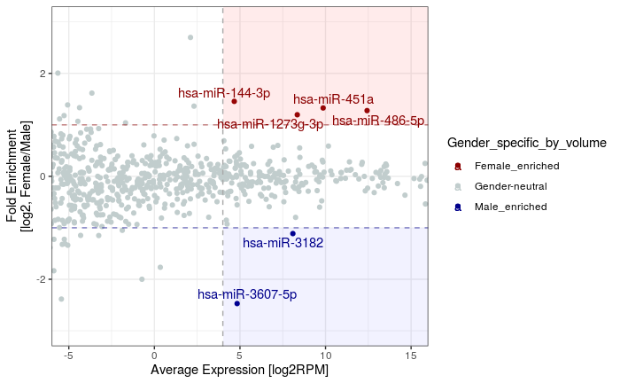

```r
### miR_DFC_DE_log : log -> mean -> fold change
### miR_DFC_DE_each : log -> fold change -(new variable)-> mean/std (그 과정에서 RPM값으로 t-test를 별도로 진행하여 해당 값만 추출)
miR_DFC_DE_final <- merge(miR_DFC_DE_log, miR_DFC_DE_each, by="miRNA", all=TRUE) %>% select(miRNA, F, M, Fold_Enrichment, Average_expression, Q_score)

miR_DFC_DE_final <- miR_DFC_DE_final %>% mutate(Gender_specific_by_volume = case_when(
                                                    (Average_expression > 4 & Fold_Enrichment > 1)~"Female_enriched",
                                                    (Average_expression > 4 & Fold_Enrichment < -1)~"Male_enriched",
                                                    TRUE~"Gender-neutral"))

MA_miR <- miR_DFC_DE_final %>%
  group_by(Gender_specific_by_volume) %>%
  ggplot(aes(Average_expression, Fold_Enrichment,color=Gender_specific_by_volume)) +
  geom_point() +
  annotate("rect", alpha = 0.1, ymin=1,ymax=6,xmin=4,xmax=20,fill="brown1") +
  annotate("rect", alpha = 0.05, ymin=-1,ymax=-6,xmin=4,xmax=20,fill="blue") +
  scale_color_manual(values=c("darkred", "#C1CDCD", "darkblue")) +
  xlab("Average Expression [log2RPM]") +
  ylab("Fold Enrichment\n[log2, Female/Male]")+
  geom_hline(yintercept = 1, colour="darkred", linetype="dashed", alpha=0.5) +
  geom_hline(yintercept = -1, colour="darkblue", linetype="dashed", alpha=0.5) +
  geom_vline(xintercept = 4, colour="darkgrey", linetype="dashed") +
  coord_cartesian(xlim =c(-5, 15), ylim = c(-3, 3)) +
  geom_text_repel(aes(label=ifelse((Average_expression > 4 & Fold_Enrichment > 1), as.character(miRNA), ""))) +
  geom_text_repel(aes(label=ifelse((Average_expression > 4 & Fold_Enrichment < -1), as.character(miRNA), ""))) +
  theme_bw()
MA_miR
```

> Fold Enrichment = 0을 기준으로 거의 대칭을 이루고 있음

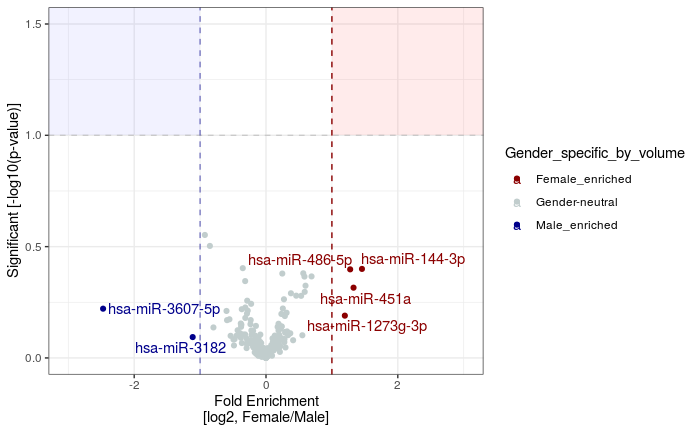

```r
Vol_miR <- miR_DFC_DE_final %>% filter(Average_expression>4) %>%
  group_by(Gender_specific_by_volume) %>%
  ggplot(aes(Fold_Enrichment, Q_score, color=Gender_specific_by_volume)) +
  geom_point() +
  annotate("rect", alpha = 0.1, ymin=1,ymax=6,xmin=1,xmax=20,fill="brown1") +
  annotate("rect", alpha = 0.05, ymin=1, ymax=6,xmin=-20,xmax=-1,fill="blue") +
  scale_color_manual(values=c("darkred", "#C1CDCD", "darkblue")) +
  xlab("Fold Enrichment\n[log2, Female/Male]") +
  ylab("Significant [-log10(p-value)]")+
  geom_hline(yintercept = 1, colour="darkgrey", linetype="dashed", alpha=0.5) +
  geom_vline(xintercept = -1, colour="darkblue", linetype="dashed", alpha=0.5) +
  geom_vline(xintercept = 1, colour="darkred", linetype="dashed") +
  coord_cartesian(xlim =c(-3, 3), ylim = c(0, 1.5)) +
  geom_text_repel(aes(label=ifelse(Gender_specific_by_volume=="Gender-neutral","",as.character(miRNA)))) +
  theme_bw()
Vol_miR
```

> 등분산 가정 시 V-shape 잘 나옴

> 안타깝게도 n수가 부족하여 statistical significant까지 얻기는 어려울 것으로 예상

> miRNA expression에 있어서 normal distribution은 negative bionomeal distribution에 비하여 보수적인 검정이었을 것이므로 negative bionomeal distribution이나 poison distribution을 통한 statistical significant test도 의미가 있을 것.

### 3.3.2 Gender specific gene identification

*지금까지의 코드 정리

```r
miR_DFC %>% head()  #tidy data
```

| donor_name | miRNA | structure | side | counts | age_group_BS | age_group | age | gender | pseudocount | RPM | log2RPM |
| --- | --- | --- | --- | --- | --- | --- | --- | --- | --- | --- | --- |
| H376.IX.50 | hsa-miR-26a-5p | DFC | L | 273362 | IX | Youth | 11 yrs | F | 273363 | 8647.2588 | 13.078027 |
| H376.IX.50 | hsa-miR-181a-5p | DFC | L | 155776 | IX | Youth | 11 yrs | F | 155777 | 4927.6751 | 12.266691 |
| H376.IX.50 | hsa-miR-143-3p | DFC | L | 176101 | IX | Youth | 11 yrs | F | 176102 | 5570.6133 | 12.443620 |
| H376.IX.50 | hsa-let-7a-5p | DFC | L | 182054 | IX | Youth | 11 yrs | F | 182055 | 5758.9239 | 12.491584 |
| H376.IX.50 | hsa-miR-9-5p | DFC | L | 100851 | IX | Youth | 11 yrs | F | 100852 | 3190.2392 | 11.639449 |
| H376.IX.50 | hsa-miR-3182 | DFC | L | 16479 | IX | Youth | 11 yrs | F | 16480 | 521.3099 | 9.025997 |

```r
tidy_to_DEG <- function(tidy_df){
  ### input
  ### 1) tidy_df : tidy data format of miRNA expression file
  ### 2) fold_enrich_df
  ### output
  ### 1) average of RPM
  ### 2) fold enrichment of average
  ### 3) Q-score
  ### 4) age group

  ### FEtemp = dataframe for calculating Fold_enrichment : method - log ration first (the same as DESeq2)
  FEtemp <- tidy_df %>%
    group_by(miRNA, gender, age_group) %>%
    summarize("average"=mean(log2RPM)) %>%
    spread(key="gender", value="average") %>%
    mutate("Fold_Enrichment" = F-M, "Average_expression"= F+M/2)

  ### Qtemp = dataframe for calculating Q-score
  Qtemp = data.frame(miRNA=c(), Q_score=c())

  for(mir in unique(tidy_df$miRNA)){
    female_log_RPMs <- tidy_df %>% filter(miRNA == mir & gender == "F") %>% .$log2RPM
    male_log_RPMs <- tidy_df %>% filter(miRNA == mir & gender == "M") %>% .$log2RPM
    temp <- data.frame(miRNA=mir,
                         Q_score = -log10(t.test(female_log_RPMs,male_log_RPMs,
                                          var.equal = ifelse(var.test(female_log_RPMs,male_log_RPMs)[["p.value"]]>0.05,
                                                             TRUE, FALSE))[["p.value"]])) #significance
    Qtemp <- rbind(Qtemp,temp)
  }

  ### Merge by miRNA : FEtemp + Qtemp
  fold_enrich_df <- merge(FEtemp, Qtemp, by='miRNA', all=TRUE)
  return (fold_enrich_df)
}

save(tidy_to_DEG, file='./BrainSpan_miR_analysis/tidy_to_DEG.RData') #tidy miRNA dataset to DEG result
```

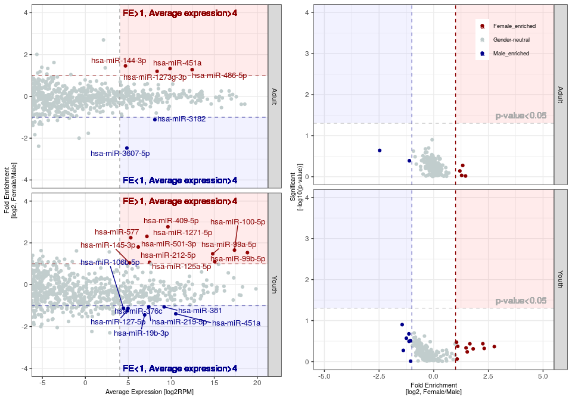

```r
miR_DFC_DE <- miR_DFC %>%
              tidy_to_DEG() %>%
              mutate(Gender_specific_by_volume = case_when((Average_expression > 4 & Fold_Enrichment > 1)~"Female_enriched",
                                                            (Average_expression > 4 & Fold_Enrichment < -1)~"Male_enriched",
                                                            TRUE~"Gender-neutral")) %>%
              mutate(Gender_specific_by_sig = case_when((Q_score > 1.3 & Fold_Enrichment > 1)~"Female_enriched",
                                                            (Q_score > 1.3 & Fold_Enrichment < -1)~"Male_enriched",
                                                            TRUE~"Gender-neutral"))
save(miR_DFC_DE, file="BrainSpan_miR_analysis/miR_DFC_DE.RData")

## Make MA plot
MA_miR_age_group <- miR_DFC_DE %>%
  group_by(Gender_specific_by_volume) %>%
  ggplot(aes(Average_expression, Fold_Enrichment,color=Gender_specific_by_volume)) +
  geom_point() +
  annotate("rect", alpha = 0.1, ymin=1,ymax=6,xmin=4,xmax=25,fill="brown1") +
  annotate("rect", alpha = 0.05, ymin=-1,ymax=-6,xmin=4,xmax=25,fill="blue") +
  scale_color_manual(values=c("darkred", "#C1CDCD", "darkblue")) +
  xlab("Average Expression [log2RPM]") +
  ylab("Fold Enrichment\n[log2, Female/Male]")+
  geom_hline(yintercept = 1, colour="darkred", linetype="dashed", alpha=0.5) +
  geom_hline(yintercept = -1, colour="darkblue", linetype="dashed", alpha=0.5) +
  geom_vline(xintercept = 4, colour="darkgrey", linetype="dashed") +
  geom_text(aes(x=11, y=4, label="FE>1, Average expression>4"), size=4, color="darkred") +
  geom_text(aes(x=11, y=-4, label="FE<1, Average expression>4"), size=4, color="darkblue") +
  coord_cartesian(xlim =c(-5, 20), ylim = c(-4, 4)) +
  geom_text_repel(aes(label=ifelse((Average_expression > 4 & abs(Fold_Enrichment) > 1), as.character(miRNA), "")), size=3.5, force=8) +
  theme_bw() +
  theme(legend.position="none",
        axis.title.x = element_text(size=8),
        axis.title.y = element_text(size=8))+
  facet_grid(age_group~.)


## Make Volcano plot
VOL_miR_age_group <- miR_DFC_DE %>%
  group_by(Gender_specific_by_volume) %>%
  filter(Average_expression > 4) %>% # threshold of gene expression
  ggplot(aes(Fold_Enrichment, Q_score, color=Gender_specific_by_volume)) +
  geom_point() +
  annotate("rect", alpha = 0.1, ymin=1.3,ymax=6,xmin=1,xmax=25,fill="brown1") +
  annotate("rect", alpha = 0.05, ymin=1.3,ymax=6,xmin=-1,xmax=-25,fill="blue") +
  scale_color_manual(values=c("darkred", "#C1CDCD", "darkblue")) +
  xlab("Fold Enrichment\n[log2, Female/Male]") +
  ylab("Significant\n[-log10(p-value)]")+
  geom_hline(yintercept = 1.3, colour="darkgrey", linetype="dashed", alpha=0.5) +
  geom_vline(xintercept = -1, colour="darkblue", linetype="dashed", alpha=0.5) +
  geom_vline(xintercept = 1, colour="darkred", linetype="dashed") +
  coord_cartesian(xlim =c(-5, 5), ylim = c(0, 4)) +
   geom_text(aes(x=4, y=1.5, label="p-value<0.05"), size=4, color="darkgrey") +
  geom_text_repel(aes(label=ifelse((Q_score > 1.3 & abs(Fold_Enrichment) > 1), as.character(miRNA), "")), size=3.5, force=8) +
  theme_bw() +
  theme(legend.position=c(0.8, 0.91),
        legend.title = element_blank(),
        legend.background=element_blank(),
        legend.text=element_text(size=7),
        axis.title.x = element_text(size=8),
        axis.title.y = element_text(size=8))+
  facet_grid(age_group~.)

library(cowplot)

DEGplot_age <- ggdraw() +
  draw_plot(MA_miR_age_group, x = 0, y = 0, width = .5, height = 1) +
  draw_plot(VOL_miR_age_group, x=.5, y = 0, width = .5, height = 1 )
save_plot("DEGplot_age.png", DEGplot_age)
save(DEGplot_age, file="./BrainSpan_miR_analysis/DEGplot_age.RData")
DEGplot_age
```

> volcano shape가 reference들과 다른 이유는 F-test를 통하여 분산검정 과정에 Sample 수가 적어 이분산검정으로 넘어간 sample이 많아졌기 때문

> plot1 아쉬운 점
1. 통계적 유의성이 떨어짐
2. Fold enrichment-Average Expression plot에서 Avg Exp.의 SEM을 함께 확인할 수 있으면 좋았을 듯.
- Q-score가 뒷받침 함.
- 실력이 늘면 추가하는 방향으로… 현재 data wrangling 과정에서 어려움을 겪었음.

### 3.3.3 2차성징 이전과 2차성징 이후의 gender-specific miRNA의 발현 양상 관찰

- Sexspecific gene을 volume 기준으로 선정한 miRNA를 gender specific miRNA라 가정하고 연령에 따른 변화 양상 파악

```r
load("./BrainSpan_miR_analysis/miR_DFC_DE.RData")
miR_DFC_DE %>%
  filter(Gender_specific_by_volume != "Gender-neutral") %>%
  group_by(age_group) %>%
  summarize("#_of_gender_sepecific_miRNA"=n_distinct(miRNA))
```

| age_group | #_of_gender_sepecific_miRNA |
| --- | --- |
| Adult | 6 |
| Youth | 17 |

```r
str(miR_DFC_DE) #processed data set
```

```
'data.frame':   3722 obs. of  9 variables:
 $ miRNA                    : chr  "hsa-let-7a-2-3p" "hsa-let-7a-2-3p" "hsa-let-7a-3p" "hsa-let-7a-3p" ...
 $ age_group                : chr  "Adult" "Youth" "Adult" "Youth" ...
 $ F                        : num  -4.32 -4.62 2.32 2.2 11.7 ...
 $ M                        : num  -4.1 -3.6 2.31 3.05 11.72 ...
 $ Fold_Enrichment          : num  -0.2239 -1.014 0.0109 -0.8421 -0.0206 ...
 $ Average_expression       : num  -6.37 -6.42 3.48 3.73 17.56 ...
 $ Q_score                  : num  0.556 0.556 0.43 0.43 0.14 ...
 $ Gender_specific_by_volume: chr  "Gender-neutral" "Gender-neutral" "Gender-neutral" "Gender-neutral" ...
 $ Gender_specific_by_sig   : chr  "Gender-neutral" "Gender-neutral" "Gender-neutral" "Gender-neutral" ...
```

```r
miR_DFC_DE<-miR_DFC_DE %>% mutate(age_specific=case_when((Gender_specific_by_volume!="Gender-neutral" & age_group == "Adult")~"adult_specific",
                                              (Gender_specific_by_volume!="Gender-neutral" & age_group == "Youth")~"youth_specific",
                                              TRUE ~ "Gender-neutral"))

#연령에 따른 gender specific miRNA 추출 (대응하는 상대방 연령그룹의 FC값이 없음)
adult_miR <- miR_DFC_DE %>% filter(age_specific=="adult_specific") %>% pull(miRNA)
youth_miR <- miR_DFC_DE %>% filter(age_specific=="youth_specific") %>% pull(miRNA)

#해당 miRNA에 대응하는 상대 연령대의 Fold expression 추출
adult_miR <- miR_DFC_DE %>% subset(miRNA %in% adult_miR)
youth_miR <- miR_DFC_DE %>% subset(miRNA %in% youth_miR)
save(adult_miR,file='./BrainSpan_miR_analysis/adult_specific_gender_miRNA.RData')
save(youth_miR,file="./BrainSpan_miR_analysis/youth_specific_gender_miRNA.RData")
```

```r
load('./BrainSpan_miR_analysis/adult_specific_gender_miRNA.RData')
load("./BrainSpan_miR_analysis/youth_specific_gender_miRNA.RData")
#Make slope chart
MA_adult <- adult_miR %>% ggplot(aes(age_group, Fold_Enrichment, group=miRNA, color=Gender_specific_by_volume)) +
                geom_line()+
                geom_text_repel(aes(label=ifelse(age_group=="Adult",miRNA,"")), size=3.5, nudge_x=-0.01, nudge_y=0.01, force=25)+
                geom_point(size=3.5)+
                scale_x_discrete(limits=c("Youth", "Adult")) +
                coord_cartesian(ylim = c(-3, 3)) +
                xlab("") +
                ylab("") +
                ggtitle("Adult Specific") +
                theme(plot.title=element_text(size=10))+
                theme_bw()

MA_youth <- youth_miR %>% ggplot(aes(age_group, Fold_Enrichment, group=miRNA, color=Gender_specific_by_volume)) +
                geom_line()+
                geom_text_repel(aes(label=ifelse(age_group=="Youth",miRNA,"")), size=3.5, nudge_x=-0.01, force=30)+
                geom_point(size=3.5)+
                scale_x_discrete(limits=c("Youth", "Adult")) +
                coord_cartesian(ylim = c(-3, 3)) +
                xlab("") +
                ylab("") +
                ggtitle("Youth Specific") +
                theme(plot.title=element_text(size=10))+
                theme_bw()

library(ggpubr)
SLOPE_age <- ggarrange(MA_youth, MA_adult, common.legend=TRUE, legend="bottom")
SLOPE_age <- annotate_figure(SLOPE_age,
                left = text_grob("Fold Enrichment\n[log2(Female/Male)]", color = "black", rot = 90, size=10))
save_plot("SLOPE_age.png", SLOPE_age)
```

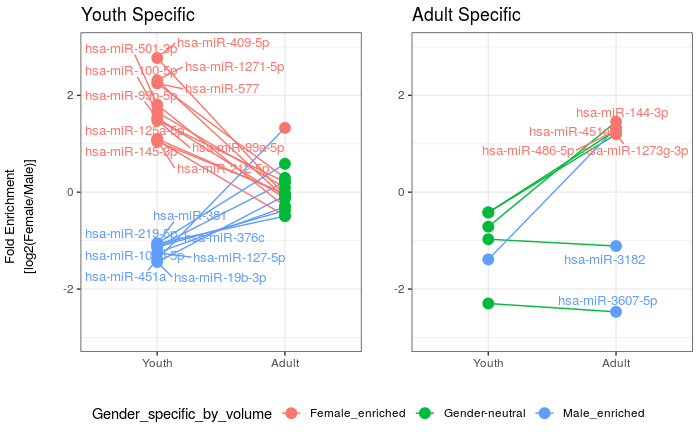

```r
save(SLOPE_age, file="./BrainSpan_miR_analysis/SLOPE_age.RData")
SLOPE_age
```

> 연령에 따라 뇌의 성별에 직접적으로 영향을 주는 miRNA가 다르다는 것을 추정할 수 있음

# 4. mRNA analysis

Q: 연령에 따라 DFC부분의 miRNA의 발현이 달라지는 패턴을 관찰한 이전의 data를 바탕으로 해당 top3 miRNA들의 target repression 여부를 확인하여 뇌의 성별결정에 있어서 miRNA에 의한 post-translational regulation이 역할을 하는지 추측해본다.

- top3 miRNA와 target list –> [TargetScanHuman](http://www.targetscan.org/vert_72/)의 annotation 이용
- 이유는 모르겠지만, R cloud 서버에 해당 파일들을 다운받으면 계속 interrupt되어 local에서 만들어서 업로드함.

reference) - hsa-miR-144-3p target : http://www.targetscan.org/vert_72/temp/TargetScan7.2__miR-144-3p.predicted_targets.xlsx - hsa-miR-451a target : http://www.targetscan.org/vert_72/temp/TargetScan7.2__miR-451.predicted_targets.txt - hsa-miR-486-5p target : http://www.targetscan.org/vert_72/temp/TargetScan7.2__miR-486-5p.predicted_targets.txt - hsa-miR-409-5p target : http://www.targetscan.org/vert_72/temp/TargetScan7.2__miR-409-5p.predicted_targets.txt - hsa-miR-1271-5p target : http://www.targetscan.org/vert_72/temp/TargetScan7.2__miR-96-5p_1271-5p.predicted_targets.txt - hsa-miR-577 target : http://www.targetscan.org/vert_72/temp/TargetScan7.2__miR-577.predicted_targets.txt

## 4.1 Top gender specific miRNA selection

### 4.1.1 Adult female miRNA target : `adult_FmiR`

```r
#adult_miR : adult에서 specific하게 gender specificity가 있는 miRNA group
adult_miR %>% filter(age_group=="Adult") %>% arrange(desc(Fold_Enrichment)) %>% head(n=3) %>% .$miRNA
```

```
[1] "hsa-miR-144-3p" "hsa-miR-451a"   "hsa-miR-486-5p"
```

```r
#library(tidyverse)
read_target <- function(file){
  # 파일 읽고 중복 제거해서 list로 retur
  read.table(file) %>% pull() %>% as.character() %>% unique() %>% return()
}
```

```r
adult_FmiR_target <- read_target("./miRTARGET/adult_bgfmir_target.txt")
```

### 4.1.2 Adult male miRNA : `adult_MmiR`

```r
adult_miR %>% filter(age_group=="Adult") %>% arrange(Fold_Enrichment) %>% head(n=3) %>% .$miRNA
```

```
[1] "hsa-miR-3607-5p"  "hsa-miR-3182"     "hsa-miR-1273g-3p"
```

```r
adult_MmiR_target <- read_target("./miRTARGET/adult_mmir_target.txt")
```

### 4.1.3 Youth Female miRNA : `youth_Fmir`

```r
youth_miR %>% filter(age_group=="Youth") %>% arrange(desc(Fold_Enrichment)) %>% head(n=3) %>% .$miRNA
```

```
[1] "hsa-miR-409-5p"  "hsa-miR-1271-5p" "hsa-miR-577"
```

```r
youth_Fmir_target <- read_target("./miRTARGET/youth_fmir_target.txt")
```

### 4.1.4 Youth Male miRNA : `youth_Mmir`

```r
youth_miR %>% filter(age_group=="Youth") %>% arrange(Fold_Enrichment) %>% head(n=3) %>% .$miRNA
```

```
[1] "hsa-miR-19b-3p" "hsa-miR-451a"   "hsa-miR-127-5p"
```

```r
youth_Mmir_target <- read_target("./miRTARGET/youth_mmir_target.txt")
```

```r
save(adult_FmiR_target, adult_MmiR_target, youth_Fmir_target, youth_Mmir_target, file = "./BrainSpan_miR_analysis/bgmiR_target.RData")
```

## 4.2. mRNA data preprocessing

### 4.2.1. load the data

```r
load('data_brainspan_DFC.20190928.Rdata')
load('./BrainSpan_miR_analysis/bgmiR_target.RData')
```

```r
#Check the number of adult donot
s %>% filter(grepl(c("X"),donor_name)) %>% group_by(gender) %>% summarise("# of Adult" = length(donor_name))
```

| gender | # of Adult |
| --- | --- |
| F | 6 |
| M | 5 |

### 4.2.2. wide to long

#### 4.2.2.1 preprocessing : 필요한 정보들 먼저 채우기

```r
head(s) #donor name : s$donor_name
```

| column_num | donor_id | donor_name | age | gender | structure_id | structure_acronym | structure_name |
| --- | --- | --- | --- | --- | --- | --- | --- |
| 1 | 13058 | H376.IIA.51 | 8 pcw | M | 10173 | DFC | dorsolateral prefrontal cortex |
| 2 | 12833 | H376.IIA.50 | 9 pcw | M | 10173 | DFC | dorsolateral prefrontal cortex |
| 3 | 12835 | H376.IIB.50 | 12 pcw | F | 10173 | DFC | dorsolateral prefrontal cortex |
| 4 | 12960 | H376.IIB.51 | 12 pcw | F | 10173 | DFC | dorsolateral prefrontal cortex |
| 5 | 13060 | H376.IIB.52 | 12 pcw | F | 10173 | DFC | dorsolateral prefrontal cortex |
| 6 | 12820 | H376.IIIA.50 | 13 pcw | M | 10173 | DFC | dorsolateral prefrontal cortex |

```r
head(g) #gene name : g$gene_symbol
```

|  | ensembl_gene_id | row_num | gene_symbol | gene_type |
| --- | --- | --- | --- | --- |
| 1 | ENSG00000000003 | 1 | TSPAN6 | protein_coding |
| 2 | ENSG00000000005 | 2 | TNMD | protein_coding |
| 3 | ENSG00000000419 | 3 | DPM1 | protein_coding |
| 4 | ENSG00000000457 | 4 | SCYL3 | protein_coding |
| 5 | ENSG00000000460 | 5 | C1orf112 | protein_coding |
| 6 | ENSG00000000938 | 6 | FGR | protein_coding |

```r
head(e) # wide format // colume -> donor_name, row -> gene_symbol => make it long
```

|  | X1 | X2 | X3 | X4 | X5 | X6 | X7 | X8 | X9 | X10 | X11 | X12 | X13 | X14 | X15 | X16 | X17 | X18 | X19 | X20 | X21 | X22 | X23 | X24 | X25 | X26 | X27 | X28 | X29 | … |
| --- | --- | --- | --- | --- | --- | --- | --- | --- | --- | --- | --- | --- | --- | --- | --- | --- | --- | --- | --- | --- | --- | --- | --- | --- | --- | --- | --- | --- | --- | --- |
| 1 | 44.943915 | 21.538118 | 6.913950 | 4.392063 | 9.726962 | 8.635878 | 8.980004 | 5.699286 | 10.405606 | 9.230360 | 15.258228 | 6.947937 | 6.450161 | 5.272812 | 10.046465 | 6.544657 | 11.511747 | 17.413425 | 5.480299 | 3.894318 | 3.050565 | 4.608069 | 3.575534 | 4.570302 | 6.249561 | 3.703572 | 3.329707 | 2.134030 | 5.433384 | … |
| 2 | 0.181220 | 0.025361 | 0.019007 | 0.095716 | 0.024831 | 0.000000 | 0.063265 | 0.000000 | 0.035032 | 0.000000 | 0.025624 | 0.000000 | 0.000000 | 0.020691 | 0.032083 | 0.000000 | 0.042915 | 0.253863 | 0.000000 | 0.158919 | 0.049913 | 0.103760 | 0.000000 | 0.073552 | 0.211106 | 0.374550 | 0.093023 | 0.089210 | 0.096181 | … |
| 3 | 38.157569 | 14.362518 | 11.509168 | 13.346579 | 17.028758 | 10.936272 | 9.654306 | 18.762400 | 14.955870 | 6.216789 | 18.712099 | 7.351731 | 10.765165 | 9.795354 | 11.552110 | 6.551851 | 10.272604 | 12.330243 | 9.958665 | 15.535817 | 8.683676 | 8.226135 | 5.875502 | 15.463342 | 12.777526 | 6.080309 | 9.929917 | 10.939239 | 12.609470 | … |
| 4 | 3.609830 | 3.821916 | 2.809731 | 2.257915 | 3.326312 | 2.464164 | 3.307770 | 1.016831 | 2.984438 | 2.497030 | 3.798596 | 2.574319 | 2.449230 | 2.251059 | 3.107960 | 1.306514 | 1.486104 | 2.237223 | 1.786255 | 1.834511 | 2.493295 | 0.717964 | 1.544906 | 1.237529 | 2.094056 | 0.987313 | 1.813739 | 1.963937 | 1.632941 | … |
| 5 | 3.560650 | 4.220291 | 1.027928 | 0.873352 | 1.259341 | 0.739733 | 1.384921 | 0.851626 | 1.410908 | 0.818434 | 1.336469 | 1.218525 | 1.004806 | 0.943555 | 1.069416 | 0.590197 | 0.552276 | 1.011569 | 0.607478 | 0.647149 | 0.698043 | 0.391726 | 0.717449 | 0.628561 | 0.629649 | 0.268103 | 0.556223 | 0.627384 | 0.731818 | … |
| 6 | 0.260205 | 0.115094 | 0.250436 | 0.195323 | 0.148888 | 0.067514 | 0.241017 | 0.121462 | 0.318183 | 0.860587 | 0.196661 | 0.289673 | 0.178150 | 0.348394 | 1.195495 | 3.232295 | 2.185150 | 2.573919 | 0.383240 | 0.886108 | 0.856158 | 3.081243 | 2.351799 | 0.929700 | 2.015151 | 0.425816 | 0.680433 | 1.591153 | 0.692244 | … |

```r
names(e) <- s$donor_name
gene_symbol <- g %>% select(gene_symbol)
e <- cbind(gene_symbol, e)
e %>% head() # wide format 완성
```

|  | gene_symbol | H376.IIA.51 | H376.IIA.50 | H376.IIB.50 | H376.IIB.51 | H376.IIB.52 | H376.IIIA.50 | H376.IIIA.51 | H376.IIIA.52 | H376.IIIB.50 | H376.IIIB.51 | H376.IIIB.52 | H376.IIIB.53 | H376.IV.53 | H376.IV.54 | H376.IV.50 | H376.V.52 | H376.V.53 | H376.VI.51 | H376.VI.52 | H376.VII.51 | H376.VIII.51 | H376.VIII.53 | H376.VIII.54 | H376.VIII.50 | H376.IX.51 | H376.IX.52 | H376.IX.50 | H376.X.51 | … |
| --- | --- | --- | --- | --- | --- | --- | --- | --- | --- | --- | --- | --- | --- | --- | --- | --- | --- | --- | --- | --- | --- | --- | --- | --- | --- | --- | --- | --- | --- | --- |
| 1 | TSPAN6 | 44.943915 | 21.538118 | 6.913950 | 4.392063 | 9.726962 | 8.635878 | 8.980004 | 5.699286 | 10.405606 | 9.230360 | 15.258228 | 6.947937 | 6.450161 | 5.272812 | 10.046465 | 6.544657 | 11.511747 | 17.413425 | 5.480299 | 3.894318 | 3.050565 | 4.608069 | 3.575534 | 4.570302 | 6.249561 | 3.703572 | 3.329707 | 2.134030 | … |
| 2 | TNMD | 0.181220 | 0.025361 | 0.019007 | 0.095716 | 0.024831 | 0.000000 | 0.063265 | 0.000000 | 0.035032 | 0.000000 | 0.025624 | 0.000000 | 0.000000 | 0.020691 | 0.032083 | 0.000000 | 0.042915 | 0.253863 | 0.000000 | 0.158919 | 0.049913 | 0.103760 | 0.000000 | 0.073552 | 0.211106 | 0.374550 | 0.093023 | 0.089210 | … |
| 3 | DPM1 | 38.157569 | 14.362518 | 11.509168 | 13.346579 | 17.028758 | 10.936272 | 9.654306 | 18.762400 | 14.955870 | 6.216789 | 18.712099 | 7.351731 | 10.765165 | 9.795354 | 11.552110 | 6.551851 | 10.272604 | 12.330243 | 9.958665 | 15.535817 | 8.683676 | 8.226135 | 5.875502 | 15.463342 | 12.777526 | 6.080309 | 9.929917 | 10.939239 | … |
| 4 | SCYL3 | 3.609830 | 3.821916 | 2.809731 | 2.257915 | 3.326312 | 2.464164 | 3.307770 | 1.016831 | 2.984438 | 2.497030 | 3.798596 | 2.574319 | 2.449230 | 2.251059 | 3.107960 | 1.306514 | 1.486104 | 2.237223 | 1.786255 | 1.834511 | 2.493295 | 0.717964 | 1.544906 | 1.237529 | 2.094056 | 0.987313 | 1.813739 | 1.963937 | … |
| 5 | C1orf112 | 3.560650 | 4.220291 | 1.027928 | 0.873352 | 1.259341 | 0.739733 | 1.384921 | 0.851626 | 1.410908 | 0.818434 | 1.336469 | 1.218525 | 1.004806 | 0.943555 | 1.069416 | 0.590197 | 0.552276 | 1.011569 | 0.607478 | 0.647149 | 0.698043 | 0.391726 | 0.717449 | 0.628561 | 0.629649 | 0.268103 | 0.556223 | 0.627384 | … |
| 6 | FGR | 0.260205 | 0.115094 | 0.250436 | 0.195323 | 0.148888 | 0.067514 | 0.241017 | 0.121462 | 0.318183 | 0.860587 | 0.196661 | 0.289673 | 0.178150 | 0.348394 | 1.195495 | 3.232295 | 2.185150 | 2.573919 | 0.383240 | 0.886108 | 0.856158 | 3.081243 | 2.351799 | 0.929700 | 2.015151 | 0.425816 | 0.680433 | 1.591153 | … |

#### 4.2.2.2 wide to long

```r
e <- e %>% gather(key="donor_name", value="RPKM", starts_with('H'), factor_key=FALSE)
e %>% summarize("#_of_donor" = n_distinct(donor_name))
```

| #_of_donor |
| --- |
| 35 |

```
#practice
names(e)[3] <-c("log2RPKM")
e %>% mutate(log2RPKM=log2(log2RPKM))
```

#### 4.2.2.3 나머지 일련정보 추가

- 필요한 일련정보 : donor_name, gender, age_group(FETUS제외)

```r
s_sub <- s %>% mutate("age_group_BS"=as.factor(do.call('rbind',strsplit(donor_name, split=".", fixed=TRUE))[,2])) %>%
               mutate("age_group"=case_when(age_group_BS %in% c("X", "XI")~"Adult",
                                  age_group_BS %in% c("VI", "VII", "VIII", "IX")~"Youth",
                                  TRUE ~ "Fetus")) %>%
      select(donor_name, gender,age_group) %>%
      filter(age_group != "Fetus")
s_sub
```

| donor_name | gender | age_group |
| --- | --- | --- |
| H376.VI.51 | M | Youth |
| H376.VI.52 | M | Youth |
| H376.VII.51 | M | Youth |
| H376.VIII.51 | F | Youth |
| H376.VIII.53 | F | Youth |
| H376.VIII.54 | M | Youth |
| H376.VIII.50 | M | Youth |
| H376.IX.51 | M | Youth |
| H376.IX.52 | M | Youth |
| H376.IX.50 | F | Youth |

[output cut: 8 more lines]

- log transformation

```r
e <- e %>% mutate(log2RPKM=log2(RPKM)) %>% select(gene_symbol, donor_name, log2RPKM)
```

```r
e <- merge(e, s_sub, by='donor_name', all=FALSE)
e%>%head()
```

|  | donor_name | gene_symbol | log2RPKM | gender | age_group |
| --- | --- | --- | --- | --- | --- |
| 1 | H376.IX.50 | TSPAN6 | 1.7353952 | F | Youth |
| 2 | H376.IX.50 | TNMD | -3.4262687 | F | Youth |
| 3 | H376.IX.50 | DPM1 | 3.3117817 | F | Youth |
| 4 | H376.IX.50 | SCYL3 | 0.8589669 | F | Youth |
| 5 | H376.IX.50 | C1orf112 | -0.8462647 | F | Youth |
| 6 | H376.IX.50 | FGR | -0.5554750 | F | Youth |

```r
save(e, file = "./BrainSpan_miR_analysis/DFC_mRNA_tidy.RData")
```

#### 4.2.2.4 cumulative fraction

```r
load('./BrainSpan_miR_analysis/DFC_mRNA_tidy.RData')
load('./BrainSpan_miR_analysis/bgmiR_target.RData')
```

- calculating the fold change of mRNA expression

```r
e <- e %>%
  group_by(gene_symbol, gender, age_group) %>%
  summarize("average"=mean(log2RPKM)) %>%
  spread(key="gender", value="average") %>%
  mutate("Fold_Enrichment"=F-M)
```

```r
Youth <- e %>% filter(age_group=="Youth")
CUM_youth <- ggplot() +
  stat_ecdf(aes(Youth$Fold_Enrichment),color="darkgrey") +
  stat_ecdf(aes(Youth %>% filter(gene_symbol %in% youth_Fmir_target) %>% .$Fold_Enrichment), color="red") +
  stat_ecdf(aes(Youth %>% filter(gene_symbol %in% youth_Mmir_target) %>% .$Fold_Enrichment), color="blue") +
  geom_text(aes(x=-1, y=1, label = "Target of female specific miRNA in DFC"), color = "red", hjust=0, size=4) +
  geom_text(aes(x=-1, y=0.92, label = "Target of male specific miRNA in DFC"), color = "blue", hjust=0, size=4) +
  geom_text(aes(x=-1, y=0.84, label = "Total mRNA in DFC"), color = "Darkgrey", hjust=0, size=4) +
  xlim(c(-1,1)) +
  ylim(c(0,1))+
  xlab("Fold Enrichment [log2(Female/Male)]")+
  ylab("") +
  geom_vline(xintercept = 0, colour="darkgrey", linetype="dashed") +
  theme_bw()
```

```r
Adult <- e %>% filter(age_group=="Adult")
CUM_adult <- ggplot() +
  stat_ecdf(aes(Adult$Fold_Enrichment),color="darkgrey") +
  stat_ecdf(aes(Adult %>% filter(gene_symbol %in% adult_FmiR_target) %>% .$Fold_Enrichment), color="red") +
  stat_ecdf(aes(Adult %>% filter(gene_symbol %in% adult_MmiR_target) %>% .$Fold_Enrichment), color="blue") +
  geom_text(aes(x=-1, y=1, label = "Target of female specific miRNA in DFC"), color = "red", hjust=0, size=4) +
  geom_text(aes(x=-1, y=0.92, label = "Target of male specific miRNA in DFC"), color = "blue", hjust=0, size=4) +
  geom_text(aes(x=-1, y=0.84, label = "Total mRNA in DFC"), color = "Darkgrey", hjust=0, size=4) +
  xlim(c(-1,1)) +
  ylim(c(0,1))+
  xlab("Fold Enrichment [log2(Female/Male)]")+
  ylab("") +
  geom_vline(xintercept = 0, colour="darkgrey", linetype="dashed") +
  theme_bw()
```

```r
load("./BrainSpan_miR_analysis/SLOPE_age.RData")
CUM_sum <- ggarrange(CUM_youth, CUM_adult)
```

[output not shown]

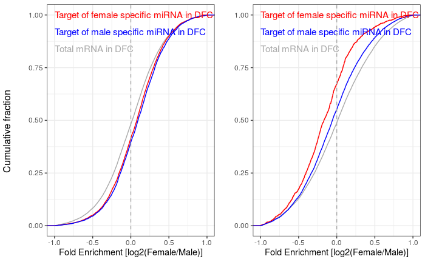

```r
CUM_sum <- annotate_figure(CUM_sum,
                left = text_grob("Cumulative fraction", color = "black", rot=90))
save(CUM_sum, file='./BrainSpan_miR_analysis/bg_target_cumilative.RData')
CUM_sum
```

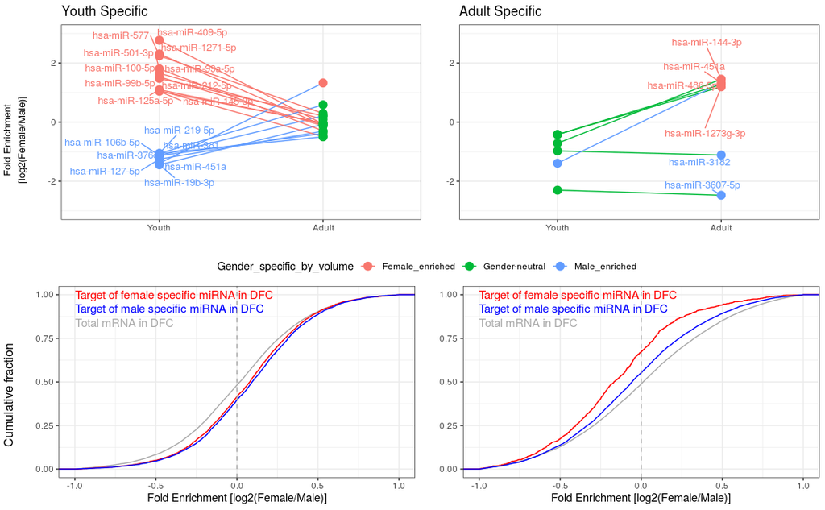

```r
load('./BrainSpan_miR_analysis/bg_target_cumilative.RData')
load('./BrainSpan_miR_analysis/SLOPE_age.RData')
SLOPE_CUM <-  ggdraw() +
  draw_plot(SLOPE_age, x = 0, y = 0.45, width = 1, height = 0.55) +
  draw_plot(CUM_sum, x=0, y = 0, width = 1, height = 0.45)
SLOPE_CUM
```

```r
save(SLOPE_CUM, file='./BrainSpan_miR_analysis/SLOPE_CUM.RData')
```

# 5.정리

plot1 :

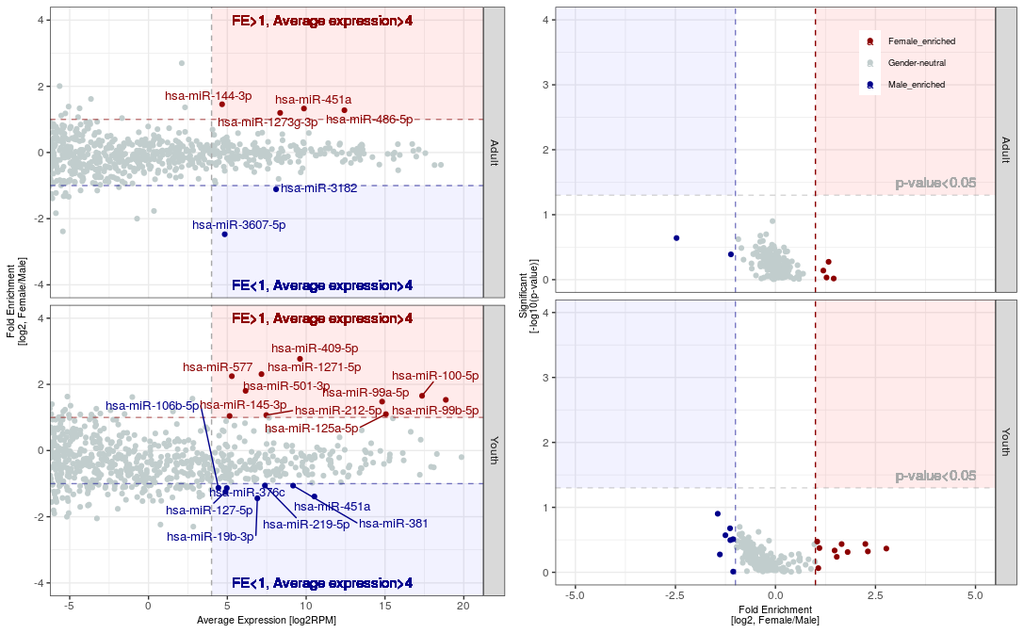

```r
load('./BrainSpan_miR_analysis/DEGplot_age.RData')
load('./BrainSpan_miR_analysis/SLOPE_CUM.RData')

DEGplot_age
```

> 2차성징 이전과 이후, DFC region에서 발현되는 miRNA의 변화를 확인하였다. 먼저 miRNA expression을 기준으로 log2RPM>4인 miRNA들에서 여성과 남성의 RPM 비율이 2배 이상 나는 miRNA들을 성별 결정에 영향을 주는 miRNA 후보로 선정하였다. 각 후보는 Youth와 Adult에서 서로 다른 분포를 보였다. 하지만 안타깝게도 n=2라는 한계로 인하여, 해당 cut-off에서 t-test 기준 통계적으로 유의한 변화를 보이는 miRNA는 존재하지 않았다.

> 이는 DFC region에 성별에 의하여 서로 상이한 발현을 보이는 miRNA가 없을 것이라고도 생각할 수 있으나, donor의 수가 제한적이므로, Average Expression 기준으로 cut-off를 넘은 miRNA 전체를 성별에 따라 발현이 다른 miRNA 후보로 선정하였다.

plot2 :

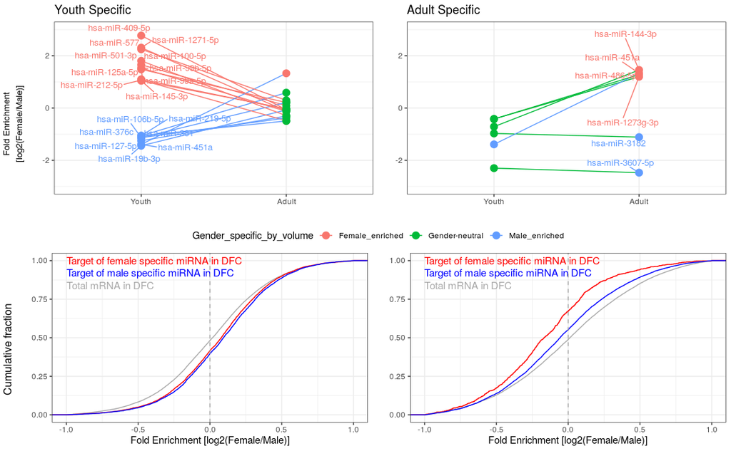

```r
SLOPE_CUM
```

> 선정된 miRNA이 실제로 특정 연령대에서만 specificity를 보이는 miRNA인지 알아보기 위하여 Youth-specific&Gender-specific miRNA와 Adult-specific&Gender-specific miRNA가 연령 변화에 따라 어떠한 양상을 보이는지 살펴보았다. 대부분의 Gender-specific miRNA들은 특정 연령에서만 성별 특이적 발현 양상을 보이며, 해당 시기를 지나거나 이전에는 성별 특이적 발현 양상이 보이지 않는다는 것을 알 수 있었다.

> 해당 miRNA들이 실제로 작동하는지를 알아보기 위하여 해당 miRNA target list를 target scan에서 수집하였다. Brain-Span에서 제공된 DFC region의 mRNA expression 정보에서 성별 특이적 miRNA target들이 실제로 repression되는지 cumulative fraction의 변화를 통하여 확인하였다.
1. Youth 시기 : Female specific miRNA target들은 감소하는 경향이 아닌 증가하는 경향을 보였다. 이는 target scan에서 제공하는 miRNA target list가 putative target이므로 매우 보수적인 검정에 속한다고 볼 수 있기에 확답을 내리기는 어려울 것이나, youth 시기의 female enriched miRNA는 역할을 하지 않을 가능성이 높을 것으로 추측된다. 반면 male enriched miRNA의 target들은 전체 mRNA의 foled enrichment에 비하여 증가하는 양상을 보였다. 따라서 Youth시기에는 male enriched miRNA가 더욱 활발히 작동할 것으로 추측된다. 이는 형태적/기능적 측면에서도 female이 default로서 발생하는 생물학적 현상을 일부 반영하는 것이 아닐까 추측된다. 즉, female형 DFC가 먼저 발생한 후 miRNA에 의한 post-transcriptional regulation에 의하여 특정 mRNA들의 발현양상이 변화하며, 이로서 male 특이적인 DFC가 형성되는 것이 아닐까 추측한다.
2. Aduct 시기 : Youth 시기와 반대로 Female 특이적인 miRNA들이 강력하게 작동하는 것으로 보인다. 이는 가임기에 도달한 후 시작되는 여성들의 호르몬 주기에 의하여 특정 miRNA들이 활발히 발현하고, 이 발현 양상이 DFC영역에 강력하게 영향을 주는 것이 아닐까 추측된다.

아쉽게도 본 데이터들은 통계적 유의성을 확보하기에 부족한 donor 수를 지니고 있어 정확한 분석이 어렵다. 이를 재확인 하기 위하여 TCGA의 LGG(Low Grade Glioma)환자들의 miRNA expression 정보를 추가하여 추가 분석을 진행하는 방향이 바람직할 것으로 보인다. 또한 mouse에서의 발현 양상도 이를 반영하는지 확인하여, loss-of-function study, gain-of-function study를 할 수 있는 실험 모델을 확립하고 동물실험을 통하여 DFC에서의 해당 miRNA들의 역할을 규명할 수 있다면, 이번 분석의 진위를 가릴 수 있을 것으로 보인다.

# 6. Reviewer comment_Update_191214

• 우선 그래프를 살펴보면 왼쪽은 fold-enrichment와 average expression에 관하여 표현하였고 오른쪽은 pvalue와 fold enrichment에 관하여 표현하였다. 왼쪽 그래프부터 살펴보면 fold enrichment 즉, 두 값을 비교하여 설명하였는데 youth 시기에는 여자-mirna는 증가하는 경향을 보이고, 남자또한 증가하는 경향을 보인다. Average expression의 차이가 2배 이상 나는 값들을 표현한것으로 보인다. (average expression>4임을 보았을때 ). 또한 fold enrichment값을 보앗을때 남자와 여자가 각각 성별결정에 유의미한 mirna들을 표현하였다.

• 오른쪽 그래프를 살펴보면 pvalue가 -log10값을 기준으로 0~1사이에 존재하는데 대부분 0에 존재하지 않고 0~1사이에 존재하므로 유의값으로써 신뢰도가 떨어지는 그래프라고 볼수 있다.

• 장점으로는 남여 성별 결정의 결정적인 mirna 관하여 작성자의 의견 즉 2배차이 이상 나는 것들을 모아서 표현한 점이 잘한것같다.

• 우선 이 그래프의 절반은 필요가 없다. 말하고자 하는 바는 아마 어렸을때와 성인것을 비교함으로 보아서, 성별결정에 어떠한 mirna가 영향을 미치는지에 관하여 그림을 그리신것같다. 우선 p값과 fold enrichment를 나타낸것은 의미가 없는것같다. P값은 유의 값으로 그저 이 통계결과가 신뢰도가 있는지에 관한 여부만 나타낼뿐 그 것으로 해석할것은 없기 때문이다. 왼쪽의 그래프를 보면 성별결정에 결정적인 역할을 하는 mirna에 관하여 적었는데, 이들이 어떠한 mi rna인지 잘 보이지 않는다.

> 해당 내용을 보완하여 volcano plot을 다시 ploting하고자 하였습니다. 데이터의 샘플이 충분히 많지 않아 발생한 통계적 유의성의 한계문제로 아래 TCGA data를 추가하여 재분석하고자 하였습니다.

> TCGA data LGG(Low Grade Glioma) data link

> 하지만 data가 정리되어 있는 방식이 BrainSpan과 TCGA가 상이하여 같은 분석을 하기 위하여 새로운 스크립트를 많이 추가해야한다는 번거로움이 있었습니다.

> 우선 이 figure의 목적은 통계적유의성에는 한계가 있으나, 성별에 따라 연령이 경과할수록 변화하는 miRNA가 존재한다는 것을 보이고, 이를 바탕으로 다음 figure에서 연령 추적 결과 실제 연령에 따라 gender specificity가 변화하며, target repression 효과가 존재하는 것을 보인 것으로 TCGA data까지 추가 분석을 하는 것은 시간 내에 무리가 있다고 판단되었습니다. 해당 데이터만으로도 과제에서 주장하고자 하는 내용을 뒷받침할 수 있다고 판단하여 이 부분에 대하여서는 기존 원안을 유지하였습니다.

• 내가 이 그래프를 고치게 되면 point값을 좀더 키워 누구나 알아볼수 있게끔 mirna를 쓰고 싶다.

> figure 크기와 폰트 사이즈를 조정하였습니다.